# New developments in r-spatial

May 11, 2017

@edzerpebesma

View these [slides](https://htmlpreview.github.io/?https://github.com/edzer/gsif/blob/master/gsif.html) or their [source](https://github.com/edzer/gsif)

## New developments in or around R

- tidyverse
- github
- blogs, twitter, reprex
- data science

## r-spatial

- http://r-spatial.org/ and https://github.com/r-spatial/ not to be confused with
- http://rspatial.org/
- http://github.com/r-spatial
- sf succeeding sp, sf-verse succeeding [sp-verse](https://twitter.com/csgillespie/status/854438264538845184).
- calls for follow up on raster: velox, fasterize, [tidy raster](https://github.com/ropensci/unconf17/issues/54), [stars](https://github.com/edzer/stars/blob/master/PROPOSAL.md)

## sf

Simple features are a standard for feature (mainly points, lines, polygons) data. The standard

- includes 17 geometry types,
- dominant are: `POINT`, `MULTIPOINT`, `LINESTRING`, `MULTILINESTRING`, `POLYGON`, `MULTIPOLYGON`, `GEOMETRYCOLLECTION`
- defines points in 2D, 3D, possibly with an `M` (measured) coordinate
- assumes simple (linear) interpolation between points
- has polygons as a single outer ring followed by zero or more inner rings (holes)
- has a text encoding (WKT), such as `LINESTRING(0 0,0 1,1 1)`
- has a binary encoding (WKB), used for I/O to libraries and storage in database blobs

Who use simple features? Everyone:

- GDAL
- GEOS
- lwgeom
- GeoJSON is a constrained set (epsg 4326, 7 types, polygons not crossing +/- 180E/W)
- spatial databases: PostGIS, SQLite, spatialite, GeoPackage, MySQL, …
- ESRI’s ArcGIS
- GeoSPARQL

## was anything wrong with `sp`?

No, but

- it does not implement simple features, but rather that what was around in 2003 (shapefiles)
- roundtripping simple features potentially leads to data loss
- its definition of polygon holes and the outer rings to which they belong is ambiguous and convoluted
- it doesn’t work easily with tidyverse, `Spatial` objects are not `data.frame`s

## Package `sf`:

```r
library(sf)
## Linking to GEOS 3.5.1, GDAL 2.1.3, proj.4 4.9.2, lwgeom 2.3.2 r15302
```

implements simple features in three levels: as single geometries:

```r
(p1 = st_point(c(0,1)))
## POINT(0 1)
(p2 = st_point(c(2,3)))
## POINT(2 3)
(l = st_linestring(rbind(c(0,0), c(0,1), c(1,1))))
## LINESTRING(0 0, 0 1, 1 1)
str(p1)
```

```
## Classes 'XY', 'POINT', 'sfg'  num [1:2] 0 1
```

```r
str(l)
```

```
##  XY [1:3, 1:2] 0 0 1 0 1 1
```

as set of simple features *geometries*:

```r
(p = st_sfc(p1, p2, crs = 4326))
## Geometry set for 2 features
## geometry type:  POINT
## dimension:      XY
## bbox:           xmin: 0 ymin: 1 xmax: 2 ymax: 3
## epsg (SRID):    4326
## proj4string:    +proj=longlat +datum=WGS84 +no_defs
## POINT(0 1)
## POINT(2 3)
```

as simple features: objects with geometry

```r
(st = st_sf(soil_type = c("podzol", "fluvisol"), elevation = c(55, 12), geom = p))
## Simple feature collection with 2 features and 2 fields
## geometry type:  POINT
## dimension:      XY
## bbox:           xmin: 0 ymin: 1 xmax: 2 ymax: 3
## epsg (SRID):    4326
## proj4string:    +proj=longlat +datum=WGS84 +no_defs
##   soil_type elevation       geom
## 1    podzol        55 POINT(0 1)
## 2  fluvisol        12 POINT(2 3)
class(st)
```

```
## [1] "sf"         "data.frame"
```

Note that `sf` objects *are* `data.frame`s.

This model essentially mirrors that of a geometry column of spatial databases like PostGIS. We can deal with more than one geometry column.

## How does this work? Enter *list-columns*

```r
df = data.frame(soil_type = c("podzol", "fluvisol"), elevation = c(55, 12))
df$listcolumn = list(1:2, 1:5)
df
```

```
##   soil_type elevation    listcolumn
## 1    podzol        55          1, 2
## 2  fluvisol        12 1, 2, 3, 4, 5
```

Now add a geometry list column:

```r
df$geom = p
df
```

```
##   soil_type elevation    listcolumn       geom
## 1    podzol        55          1, 2 POINT(0 1)
## 2  fluvisol        12 1, 2, 3, 4, 5 POINT(2 3)
```

```r
class(df)
```

```
## [1] "data.frame"
```

we still have a `data.frame`; so we do

```r
s = st_as_sf(df)
class(s)
```

```
## [1] "sf"         "data.frame"
```

```r
s
## Simple feature collection with 2 features and 3 fields
## geometry type:  POINT
## dimension:      XY
## bbox:           xmin: 0 ymin: 1 xmax: 2 ymax: 3
## epsg (SRID):    4326
## proj4string:    +proj=longlat +datum=WGS84 +no_defs
##   soil_type elevation    listcolumn       geom
## 1    podzol        55          1, 2 POINT(0 1)
## 2  fluvisol        12 1, 2, 3, 4, 5 POINT(2 3)
```

# Now polygons

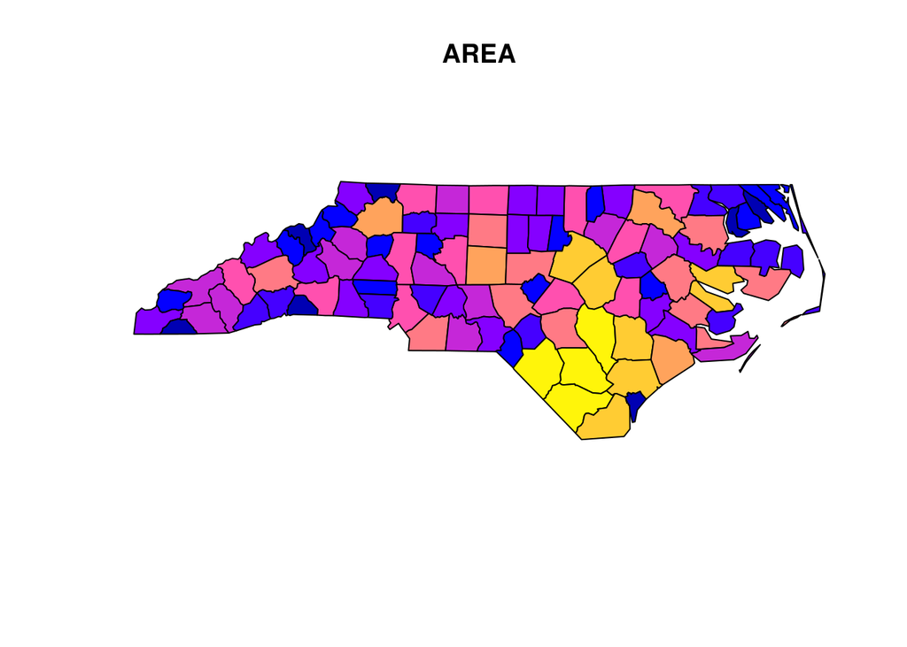

```r
nc = st_read(system.file("gpkg/nc.gpkg", package="sf"))
## Reading layer `nc.gpkg' from data source `/home/edzer/R/x86_64-pc-linux-gnu-library/3.4/sf/gpkg/nc.gpkg' using driver `GPKG'
## converted into: MULTIPOLYGON
## Simple feature collection with 100 features and 14 fields
## geometry type:  MULTIPOLYGON
## dimension:      XY
## bbox:           xmin: -84.32385 ymin: 33.88199 xmax: -75.45698 ymax: 36.58965
## epsg (SRID):    4267
## proj4string:    +proj=longlat +datum=NAD27 +no_defs
plot(nc[1])
```

but also

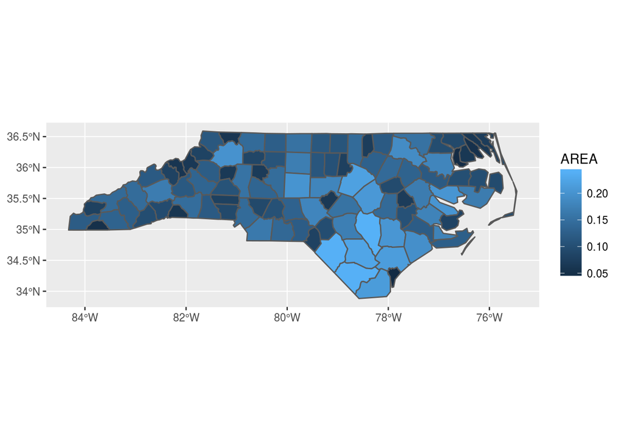

```r
library(ggplot2)
nc$geometry = nc$geom
ggplot(nc) + geom_sf(aes(fill = AREA))
```

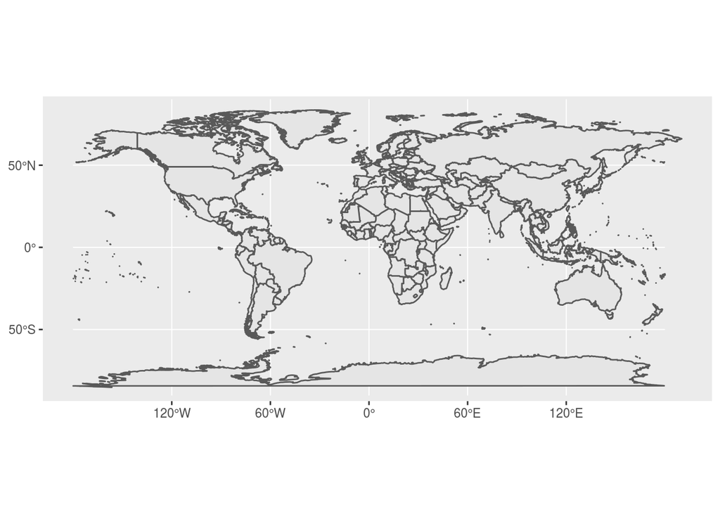

```r
# setting the aspect ratio correctly.
library(maps)
world1 <- sf::st_as_sf(map('world', plot = FALSE, fill = TRUE))
ggplot() + geom_sf(data = world1)
```

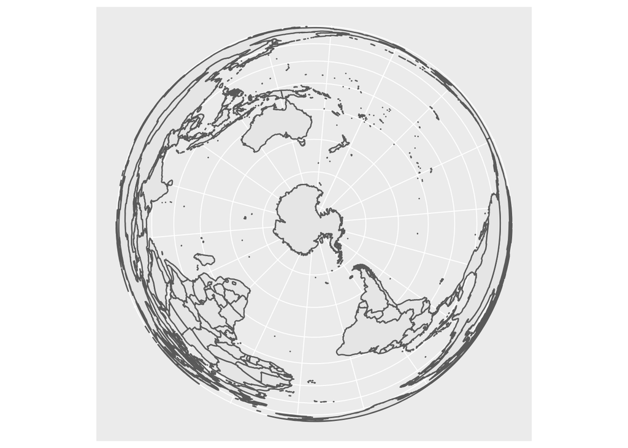

```r
world2 <- sf::st_transform(
    world1,
    "+proj=laea +y_0=0 +lon_0=155 +lat_0=-90 +ellps=WGS84 +no_defs"
)
ggplot() + geom_sf(data = world2)
```

```r
st_rook = function(a, b = a) st_relate(a, b, pattern = "F***1****")
library(dplyr)
nc <- nc %>% mutate(NB_ROOK = st_rook(.))
## although coordinates are longitude/latitude, it is assumed that they are planar
nc[1:3,]
## Simple feature collection with 3 features and 15 fields
## Active geometry column: geom
## geometry type:  MULTIPOLYGON
## dimension:      XY
## bbox:           xmin: -81.74107 ymin: 36.23388 xmax: -80.43531 ymax: 36.58965
## epsg (SRID):    4267
## proj4string:    +proj=longlat +datum=NAD27 +no_defs
##    AREA PERIMETER CNTY_ CNTY_ID      NAME  FIPS FIPSNO CRESS_ID BIR74
## 1 0.114     1.442  1825    1825      Ashe 37009  37009        5  1091
## 2 0.061     1.231  1827    1827 Alleghany 37005  37005        3   487
## 3 0.143     1.630  1828    1828     Surry 37171  37171       86  3188
##   SID74 NWBIR74 BIR79 SID79 NWBIR79           NB_ROOK
## 1     1      10  1364     0      19         2, 18, 19
## 2     0      10   542     3      12          1, 3, 18
## 3     5     208  3616     6     260 2, 10, 18, 23, 25
##                             geom                       geometry
## 1 MULTIPOLYGON(((-81.47275543... MULTIPOLYGON(((-81.47275543...
## 2 MULTIPOLYGON(((-81.23989105... MULTIPOLYGON(((-81.23989105...
## 3 MULTIPOLYGON(((-80.45634460... MULTIPOLYGON(((-80.45634460...
```